# Getting Started with Your Lab

## Getting started with your Lab Sandbox

You can find important course-specific tips and notes for your Lab Sandbox in this  
quick guide to use throughout your course. You’ll be able to reference this at any time  
or visit the [Learner Help Center](https://learner.coursera.help/hc/articles/360062301971) for more info.

Throughout this course, you'll encounter datasets which are hosted on other websites or are linked from the course instructional materials. If you'd like to complete your work in the lab sandbox environment, please download these datasets from their listed websites and upload the data files directly into your RStudio lab environment. Lab Sandboxes have limited access to external sites, so uploading your data files directly will help ensure you do not encounter any access errors.

## What tools are already installed in my sandbox environment?

- Python==3.7.6
- turicreate==6.4.1
- scikit-learn(same as sklearn)==0.22.2.post1
- pandas==1.0.3
- numpy==1.18.4
- matplotlib==3.2.1
- unzip for uploading/unpacking data and files via Jupyter's built-in Terminal

## Additional Course Specific Notes:

- IMPORTANT: To optimize your notebook performance, please shut down each of your  
  open/running Jupyter Notebooks after you complete them within your Lab.  
  This will provide full and dedicated system resources to the current lab assignment  
  you are working on in your Lab Sandbox. If you experience any unexpected slow  
  processing in your notebook, try to restart your Lab kernel and only open that single  
  notebook to complete your work. You can learn more about restarting your Lab Sandbox  
  and troubleshooting your lab in our Learner Help Center article [here](https://learner.coursera.help/hc/articles/360044758731-Solving-Common-Issues-with-Coursera-Labs).
- Ensure you are using Python3 to complete the assessments. In Python3, the print statement syntax  
  is print("Hello") rather than print "Hello" as stated in the solution files
- Upload the unzipped files to the Labs Sandbox.
- **It is highly advised to practice with turicreate if you use this sandbox** as it can be used on large datasets.  
  Turicreate and python3 will be the preferred/supported route for the sandbox,  
  to enable a newer version of python and avoid compatibility issues between versions.  
  If you prefer to have Python2 installed in your local system, you can use Sframe or graphlab locally as well.  
  You are still able to complete all assignments locally if you would prefer using other tools.
- As an important note, the sandbox environment has limited access to the internet, so you will not be  
  able to install additional packages into this sandbox. However, the required dependencies for the Python3,  
  Jupyter Notebook, and turicreate path are pre-installed. This should still allow you to complete your coursework  
  in the sandbox if you are unable to complete it locally. If you find that you are blocked using available tools in this  
  sandbox at any point, please reach out to Coursera through the Learner Help Center with your feedback!
- Decide on which tool you'd like to use at the very beginning of the course. It is highly advisable  
  not to switch between turicreate and other Python libraries such as sklearn or Pandas.
- If anything is unclear regarding the course content, please go through the  
  Discussion board and see if your question has been answered. If you have any issues  
  with the Jupyter enviornment itself, please contact Coursera through the [Learner Help Center.](https://learner.coursera.help)

## Important Note:

To use SFrame, kindly import the package turicreate, as the prior standalone SFrame package is not compatible with Python 3.X.

Run the following code to get started: from turicreate import sframe

Happy Learning!

```python
! pip install turicreate==6.4.1
```

```python
!unzip people_wiki.sframe.zip
```

```
Archive:  people_wiki.sframe.zip
replace people_wiki.sframe/m_cf05efad0f89a530.frame_idx? [y]es, [n]o, [A]ll, [N]one, [r]ename:
```

```python
from __future__ import print_function # to conform python 2.x print to python 3.x
import turicreate
import matplotlib.pyplot as plt
import numpy as np
%matplotlib inline
```

```python
wiki = turicreate.SFrame('people_wiki.sframe')
```

```python
wiki
```

| URI | name | text |
| --- | --- | --- |
| <http://dbpedia.org/resou rce/Digby_Morrell> ... | Digby Morrell | digby morrell born 10 october 1979 is a former ... |
| <http://dbpedia.org/resou rce/Alfred_J._Lewy> ... | Alfred J. Lewy | alfred j lewy aka sandy lewy graduated from ... |
| <http://dbpedia.org/resou rce/Harpdog_Brown> ... | Harpdog Brown | harpdog brown is a singer and harmonica player who ... |
| <http://dbpedia.org/resou rce/Franz_Rottensteiner> ... | Franz Rottensteiner | franz rottensteiner born in waidmannsfeld lower ... |
| <http://dbpedia.org/resou rce/G-Enka> ... | G-Enka | henry krvits born 30 december 1974 in tallinn ... |
| <http://dbpedia.org/resou rce/Sam_Henderson> ... | Sam Henderson | sam henderson born october 18 1969 is an ... |
| <http://dbpedia.org/resou rce/Aaron_LaCrate> ... | Aaron LaCrate | aaron lacrate is an american music producer ... |
| <http://dbpedia.org/resou rce/Trevor_Ferguson> ... | Trevor Ferguson | trevor ferguson aka john farrow born 11 november ... |
| <http://dbpedia.org/resou rce/Grant_Nelson> ... | Grant Nelson | grant nelson born 27 april 1971 in london ... |
| <http://dbpedia.org/resou rce/Cathy_Caruth> ... | Cathy Caruth | cathy caruth born 1955 is frank h t rhodes ... |

[59071 rows x 3 columns]  
Note: Only the head of the SFrame is printed.  
You can use print_rows(num_rows=m, num_columns=n) to print more rows and columns.

```python
wiki['word_count'] = turicreate.text_analytics.count_words(wiki['text'])
```

```python
model = turicreate.nearest_neighbors.create(wiki, label='name', features=['word_count'],
                                            method='brute_force', distance='euclidean')
```

```
Starting brute force nearest neighbors model training.
```

```
Validating distance components.
```

```
Initializing distances.
```

```
Done.
```

```python
model.query(wiki[wiki['name']=='Barack Obama'], label='name', k=10)
```

```
Starting pairwise querying.
```

```
+--------------+---------+-------------+--------------+
```

```
| Query points | # Pairs | % Complete. | Elapsed Time |
```

```
+--------------+---------+-------------+--------------+
```

```
| 0            | 1       | 0.00169288  | 3.948ms      |
```

```
| Done         |         | 100         | 407.18ms     |
```

```
+--------------+---------+-------------+--------------+
```

| query_label | reference_label | distance | rank |
| --- | --- | --- | --- |
| Barack Obama | Barack Obama | 0.0 | 1 |
| Barack Obama | Joe Biden | 33.075670817082454 | 2 |
| Barack Obama | George W. Bush | 34.39476704383968 | 3 |
| Barack Obama | Lawrence Summers | 36.15245496505044 | 4 |
| Barack Obama | Mitt Romney | 36.16628264005025 | 5 |
| Barack Obama | Francisco Barrio | 36.3318042491699 | 6 |
| Barack Obama | Walter Mondale | 36.40054944640259 | 7 |
| Barack Obama | Wynn Normington Hugh- Jones ... | 36.49657518178932 | 8 |
| Barack Obama | Don Bonker | 36.6333181680284 | 9 |
| Barack Obama | Andy Anstett | 36.959437225152655 | 10 |

[10 rows x 4 columns]

```python
def top_words(name):
    """
    Get a table of the most frequent words in the given person's wikipedia page.
    """
    row = wiki[wiki['name'] == name]
    word_count_table = row[['word_count']].stack('word_count', new_column_name=['word','count'])
    return word_count_table.sort('count', ascending=False)
```

```python
obama_words = top_words('Barack Obama')
obama_words
```

| word | count |
| --- | --- |
| the | 40.0 |
| in | 30.0 |
| and | 21.0 |
| of | 18.0 |
| to | 14.0 |
| his | 11.0 |
| obama | 9.0 |
| act | 8.0 |
| a | 7.0 |
| he | 7.0 |

[273 rows x 2 columns]  
Note: Only the head of the SFrame is printed.  
You can use print_rows(num_rows=m, num_columns=n) to print more rows and columns.

```python
barrio_words = top_words('Francisco Barrio')
barrio_words
```

| word | count |
| --- | --- |
| the | 36.0 |
| of | 24.0 |
| and | 18.0 |
| in | 17.0 |
| he | 10.0 |
| to | 9.0 |
| chihuahua | 7.0 |
| governor | 6.0 |
| a | 6.0 |
| as | 5.0 |

[225 rows x 2 columns]  
Note: Only the head of the SFrame is printed.  
You can use print_rows(num_rows=m, num_columns=n) to print more rows and columns.

```python
combined_words = obama_words.join(barrio_words, on='word')
combined_words
```

| word | count | count.1 |
| --- | --- | --- |
| the | 40.0 | 36.0 |
| in | 30.0 | 17.0 |
| and | 21.0 | 18.0 |
| of | 18.0 | 24.0 |
| to | 14.0 | 9.0 |
| his | 11.0 | 5.0 |
| a | 7.0 | 6.0 |
| he | 7.0 | 10.0 |
| as | 6.0 | 5.0 |
| was | 5.0 | 4.0 |

[56 rows x 3 columns]  
Note: Only the head of the SFrame is printed.  
You can use print_rows(num_rows=m, num_columns=n) to print more rows and columns.

```python
combined_words = combined_words.rename({'count':'Obama', 'count.1':'Barrio'})
combined_words
```

| word | Obama | Barrio |
| --- | --- | --- |
| the | 40.0 | 36.0 |
| in | 30.0 | 17.0 |
| and | 21.0 | 18.0 |
| of | 18.0 | 24.0 |
| to | 14.0 | 9.0 |
| his | 11.0 | 5.0 |
| a | 7.0 | 6.0 |
| he | 7.0 | 10.0 |
| as | 6.0 | 5.0 |
| was | 5.0 | 4.0 |

[56 rows x 3 columns]  
Note: Only the head of the SFrame is printed.  
You can use print_rows(num_rows=m, num_columns=n) to print more rows and columns.

```python
combined_words.sort('Obama', ascending=False)[:5]
```

| word | Obama | Barrio |
| --- | --- | --- |
| the | 40.0 | 36.0 |
| in | 30.0 | 17.0 |
| and | 21.0 | 18.0 |
| of | 18.0 | 24.0 |
| to | 14.0 | 9.0 |

[5 rows x 3 columns]

```python
common_words = set(combined_words.sort('Obama', ascending=False)[:5]['word']) # YOUR CODE HERE

def has_top_words(word_count_vector):
    # extract the keys of word_count_vector and convert it to a set
    unique_words = set(word_count_vector.keys())   # YOUR CODE HERE
    # return True if common_words is a subset of unique_words
    # return False otherwise
    return common_words.issubset(unique_words)  # YOUR CODE HERE

wiki['has_top_words'] = wiki['word_count'].apply(has_top_words)

# use has_top_words column to answer the quiz question
... # YOUR CODE HERE
wiki['has_top_words'].sum()
```

```
Using default 16 lambda workers.
```

```
To maximize the degree of parallelism, add the following code to the beginning of the program:
```

```
"turicreate.config.set_runtime_config('TURI_DEFAULT_NUM_PYLAMBDA_WORKERS', 32)"
```

```
Note that increasing the degree of parallelism also increases the memory footprint.
```

```
56066
```

```python
len(wiki['has_top_words'])
```

```
59071
```

```python
print('Output from your function:', has_top_words(wiki[32]['word_count']))
print('Correct output: True')
print('Also check the length of unique_words. It should be 167')
print(len(wiki[32]['word_count']))
```

```
Output from your function: True
Correct output: True
Also check the length of unique_words. It should be 167
167
```

```python
print('Output from your function:', has_top_words(wiki[33]['word_count']))
print('Correct output: False')
print('Also check the length of unique_words. It should be 188')
print(len(wiki[33]['word_count']))
```

```
Output from your function: False
Correct output: False
Also check the length of unique_words. It should be 188
188
```

```python
o = wiki[wiki['name'] == 'Barack Obama']['word_count'][0]
b = wiki[wiki['name'] == 'George W. Bush']['word_count'][0]
j = wiki[wiki['name'] == 'Joe Biden']['word_count'][0]
turicreate.toolkits.distances.euclidean(o, b)
```

```
34.39476704383968
```

```python
turicreate.toolkits.distances.euclidean(o, j)
```

```
33.075670817082454
```

```python
turicreate.toolkits.distances.euclidean(j, b)
```

```
32.7566787083184
```

```python
bush_words = top_words('George W. Bush')
combined_words = obama_words.join(bush_words, on='word')
combined_words = combined_words.rename({'count':'Obama', 'count.1':'Bush'})
combined_words.sort('Obama', ascending=False)
```

| word | Obama | Bush |
| --- | --- | --- |
| the | 40.0 | 39.0 |
| in | 30.0 | 22.0 |
| and | 21.0 | 14.0 |
| of | 18.0 | 14.0 |
| to | 14.0 | 11.0 |
| his | 11.0 | 6.0 |
| act | 8.0 | 3.0 |
| a | 7.0 | 6.0 |
| he | 7.0 | 8.0 |
| as | 6.0 | 6.0 |

[86 rows x 3 columns]  
Note: Only the head of the SFrame is printed.  
You can use print_rows(num_rows=m, num_columns=n) to print more rows and columns.

```python
wiki['tf_idf'] = turicreate.text_analytics.tf_idf(wiki['word_count'])
```

```python
model_tf_idf = turicreate.nearest_neighbors.create(wiki, label='name', features=['tf_idf'],
                                                   method='brute_force', distance='euclidean')
```

```
Starting brute force nearest neighbors model training.
```

```
Validating distance components.
```

```
Initializing distances.
```

```
Done.
```

```python
model_tf_idf.query(wiki[wiki['name'] == 'Barack Obama'], label='name', k=10)
```

```
Starting pairwise querying.
```

```
+--------------+---------+-------------+--------------+
```

```
| Query points | # Pairs | % Complete. | Elapsed Time |
```

```
+--------------+---------+-------------+--------------+
```

```
| 0            | 1       | 0.00169288  | 13.071ms     |
```

```
| Done         |         | 100         | 467.194ms    |
```

```
+--------------+---------+-------------+--------------+
```

| query_label | reference_label | distance | rank |
| --- | --- | --- | --- |
| Barack Obama | Barack Obama | 0.0 | 1 |
| Barack Obama | Phil Schiliro | 106.86101369140928 | 2 |
| Barack Obama | Jeff Sessions | 108.87167421571078 | 3 |
| Barack Obama | Jesse Lee (politician) | 109.04569790902957 | 4 |
| Barack Obama | Samantha Power | 109.10810616502708 | 5 |
| Barack Obama | Bob Menendez | 109.78186710530215 | 6 |
| Barack Obama | Eric Stern (politician) | 109.9577880796839 | 7 |
| Barack Obama | James A. Guest | 110.4138887175989 | 8 |
| Barack Obama | Roland Grossenbacher | 110.47060870018984 | 9 |
| Barack Obama | Tulsi Gabbard | 110.6969979988001 | 10 |

[10 rows x 4 columns]

```python
def top_words_tf_idf(name):
    row = wiki[wiki['name'] == name]
    word_count_table = row[['tf_idf']].stack('tf_idf', new_column_name=['word','weight'])
    return word_count_table.sort('weight', ascending=False)
```

```python
obama_tf_idf = top_words_tf_idf('Barack Obama')
obama_tf_idf
```

| word | weight |
| --- | --- |
| obama | 43.2956530720749 |
| act | 27.67822262297991 |
| iraq | 17.747378587965535 |
| control | 14.887060845181308 |
| law | 14.722935761763422 |
| ordered | 14.533373950913514 |
| military | 13.115932778499415 |
| involvement | 12.784385241175055 |
| response | 12.784385241175055 |
| democratic | 12.410688697332166 |

[273 rows x 2 columns]  
Note: Only the head of the SFrame is printed.  
You can use print_rows(num_rows=m, num_columns=n) to print more rows and columns.

```python
schiliro_tf_idf = top_words_tf_idf('Phil Schiliro')
schiliro_tf_idf
```

| word | weight |
| --- | --- |
| schiliro | 21.972990778450388 |
| staff | 15.856441635180534 |
| congressional | 13.547087656327776 |
| daschleschiliro | 10.986495389225194 |
| obama | 9.621256238238866 |
| waxman | 9.04058524016988 |
| president | 9.033586614158258 |
| 2014from | 8.683910296231149 |
| law | 7.361467880881711 |
| consultant | 6.913104037247212 |

[119 rows x 2 columns]  
Note: Only the head of the SFrame is printed.  
You can use print_rows(num_rows=m, num_columns=n) to print more rows and columns.

```python
combined_words = obama_tf_idf.join(schiliro_tf_idf, on='word')
combined_words = combined_words.rename({'weight':'Obama', 'weight.1':'Schiliro'})
combined_words.sort('Obama', ascending=False)
```

| word | Obama | Schiliro |
| --- | --- | --- |
| obama | 43.2956530720749 | 9.621256238238866 |
| law | 14.722935761763422 | 7.361467880881711 |
| democratic | 12.410688697332166 | 6.205344348666083 |
| senate | 10.164288179703693 | 3.3880960599012306 |
| presidential | 7.386955418904825 | 3.6934777094524125 |
| president | 7.226869291326606 | 9.033586614158258 |
| policy | 6.095386282141427 | 3.0476931410707135 |
| states | 5.473200989631017 | 1.824400329877006 |
| office | 5.2481728232196465 | 2.6240864116098233 |
| 2011 | 5.107041270312876 | 3.4046941802085837 |

[47 rows x 3 columns]  
Note: Only the head of the SFrame is printed.  
You can use print_rows(num_rows=m, num_columns=n) to print more rows and columns.

```python
common_words = set(combined_words.sort('Obama', ascending=False)[:5]['word']) # YOUR CODE HERE

def has_top_words(word_count_vector):
    # extract the keys of word_count_vector and convert it to a set
    unique_words = set(word_count_vector.keys())   # YOUR CODE HERE
    # return True if common_words is a subset of unique_words
    # return False otherwise
    return common_words.issubset(unique_words)  # YOUR CODE HERE

wiki['has_top_words'] = wiki['word_count'].apply(has_top_words)

# use has_top_words column to answer the quiz question
... # YOUR CODE HERE
wiki['has_top_words'].sum()

# use has_top_words column to answer the quiz question
# ...  # YOUR CODE HERE
```

```
14
```

```python
common_words
```

```
{'democratic', 'law', 'obama', 'presidential', 'senate'}
```

```python
biden_tf_idf = top_words_tf_idf('Joe Biden')
```

```python
biden_tf_idf
```

| word | weight |
| --- | --- |
| biden | 63.92610492536963 |
| obama | 19.24251247647773 |
| act | 17.298889139362444 |
| vice | 15.355736099810581 |
| resolved | 13.135309562857193 |
| senator | 11.716882477603237 |
| delaware | 11.396456717061318 |
| judiciary | 11.011712931766406 |
| dosf | 10.986495389225194 |
| thomasbiden | 10.986495389225194 |

[219 rows x 2 columns]  
Note: Only the head of the SFrame is printed.  
You can use print_rows(num_rows=m, num_columns=n) to print more rows and columns.

```python
combined_words = obama_tf_idf.join(biden_tf_idf, on='word')
combined_words['weight'], combined_words['weight.1']
```

```
(dtype: float
 Rows: 84
 [43.2956530720749, 27.67822262297991, 17.747378587965535, 14.887060845181308, 14.722935761763422, 13.115932778499415, 12.410688697332166, 11.591942692842837, 10.164288179703693, 9.43101391473379, 9.319341564760851, 8.907053847545358, 8.842460838379667, 7.712676160711769, 7.654290879049991, 7.431147…
 dtype: float
 Rows: 84
 [19.24251247647773, 17.298889139362444, 4.436844646991384, 7.443530422590654, 2.4538226269605703, 3.2789831946248538, 9.308016522999125, 9.659952244035697, 10.164288179703693, 4.715506957366895, 3.1064471882536173, 8.907053847545358, 8.842460838379667, 5.14178410714118, 7.654290879049991, 7.4311473…
```

```python
combined_words
```

| word | weight | weight.1 |
| --- | --- | --- |
| obama | 43.2956530720749 | 19.24251247647773 |
| act | 27.67822262297991 | 17.298889139362444 |
| iraq | 17.747378587965535 | 4.436844646991384 |
| control | 14.887060845181308 | 7.443530422590654 |
| law | 14.722935761763422 | 2.4538226269605703 |
| military | 13.115932778499415 | 3.2789831946248538 |
| democratic | 12.410688697332166 | 9.308016522999125 |
| us | 11.591942692842837 | 9.659952244035697 |
| senate | 10.164288179703693 | 10.164288179703693 |
| nominee | 9.43101391473379 | 4.715506957366895 |

[84 rows x 3 columns]  
Note: Only the head of the SFrame is printed.  
You can use print_rows(num_rows=m, num_columns=n) to print more rows and columns.

```python
turicreate.toolkits.distances.euclidean(list(combined_words['weight']), list(combined_words['weight.1']))
```

```
37.90533065920024
```

```python
turicreate.toolkits.distances.euclidean(wiki[wiki['name'] == 'Barack Obama']['tf_idf'][0],
                                        wiki[wiki['name'] == 'Joe Biden']['tf_idf'][0])
```

```
123.29745600964294
```

```python
model_tf_idf.query(wiki[wiki['name'] == 'Barack Obama'], label='name', k=10)
```

```
Starting pairwise querying.
```

```
+--------------+---------+-------------+--------------+
```

```
| Query points | # Pairs | % Complete. | Elapsed Time |
```

```
+--------------+---------+-------------+--------------+
```

```
| 0            | 1       | 0.00169288  | 5.258ms      |
```

```
| Done         |         | 100         | 498.118ms    |
```

```
+--------------+---------+-------------+--------------+
```

| query_label | reference_label | distance | rank |
| --- | --- | --- | --- |
| Barack Obama | Barack Obama | 0.0 | 1 |
| Barack Obama | Phil Schiliro | 106.86101369140928 | 2 |
| Barack Obama | Jeff Sessions | 108.87167421571078 | 3 |
| Barack Obama | Jesse Lee (politician) | 109.04569790902957 | 4 |
| Barack Obama | Samantha Power | 109.10810616502708 | 5 |
| Barack Obama | Bob Menendez | 109.78186710530215 | 6 |
| Barack Obama | Eric Stern (politician) | 109.9577880796839 | 7 |
| Barack Obama | James A. Guest | 110.4138887175989 | 8 |
| Barack Obama | Roland Grossenbacher | 110.47060870018984 | 9 |
| Barack Obama | Tulsi Gabbard | 110.6969979988001 | 10 |

[10 rows x 4 columns]

```python
def compute_length(row):
    return len(row['text'].split(' '))

wiki['length'] = wiki.apply(compute_length)
```

```python
nearest_neighbors_euclidean = model_tf_idf.query(wiki[wiki['name'] == 'Barack Obama'], label='name', k=100)
nearest_neighbors_euclidean = nearest_neighbors_euclidean.join(wiki[['name', 'length']], on={'reference_label':'name'})
```

```
Starting pairwise querying.
```

```
+--------------+---------+-------------+--------------+
```

```
| Query points | # Pairs | % Complete. | Elapsed Time |
```

```
+--------------+---------+-------------+--------------+
```

```
| 0            | 1       | 0.00169288  | 7.05ms       |
```

```
| Done         |         | 100         | 574.183ms    |
```

```
+--------------+---------+-------------+--------------+
```

```python
nearest_neighbors_euclidean.sort('rank')
```

| query_label | reference_label | distance | rank | length |
| --- | --- | --- | --- | --- |
| Barack Obama | Barack Obama | 0.0 | 1 | 540 |
| Barack Obama | Phil Schiliro | 106.86101369140928 | 2 | 208 |
| Barack Obama | Jeff Sessions | 108.87167421571078 | 3 | 230 |
| Barack Obama | Jesse Lee (politician) | 109.04569790902957 | 4 | 216 |
| Barack Obama | Samantha Power | 109.10810616502708 | 5 | 310 |
| Barack Obama | Bob Menendez | 109.78186710530215 | 6 | 220 |
| Barack Obama | Eric Stern (politician) | 109.9577880796839 | 7 | 255 |
| Barack Obama | James A. Guest | 110.4138887175989 | 8 | 215 |
| Barack Obama | Roland Grossenbacher | 110.47060870018984 | 9 | 201 |
| Barack Obama | Tulsi Gabbard | 110.6969979988001 | 10 | 228 |

[100 rows x 5 columns]  
Note: Only the head of the SFrame is printed.  
You can use print_rows(num_rows=m, num_columns=n) to print more rows and columns.

[output not shown]

[figure not shown]

```python
plt.figure(figsize=(10.5,4.5))
plt.hist(wiki['length'], 50, color='k', edgecolor='None', histtype='stepfilled', normed=True,
         label='Entire Wikipedia', zorder=3, alpha=0.8)
plt.hist(nearest_neighbors_euclidean['length'], 50, color='r', edgecolor='None', histtype='stepfilled', normed=True,
         label='100 NNs of Obama (Euclidean)', zorder=10, alpha=0.8)
plt.axvline(x=wiki['length'][wiki['name'] == 'Barack Obama'][0], color='k', linestyle='--', linewidth=4,
           label='Length of Barack Obama', zorder=2)
plt.axvline(x=wiki['length'][wiki['name'] == 'Joe Biden'][0], color='g', linestyle='--', linewidth=4,
           label='Length of Joe Biden', zorder=1)
plt.axis([0, 1000, 0, 0.04])

plt.legend(loc='best', prop={'size':15})
plt.title('Distribution of document length')
plt.xlabel('# of words')
plt.ylabel('Percentage')
plt.rcParams.update({'font.size':16})
plt.tight_layout()
```

```python
model2_tf_idf = turicreate.nearest_neighbors.create(wiki, label='name', features=['tf_idf'],
                                                    method='brute_force', distance='cosine')
```

```python
nearest_neighbors_cosine = model2_tf_idf.query(wiki[wiki['name'] == 'Barack Obama'], label='name', k=100)
nearest_neighbors_cosine = nearest_neighbors_cosine.join(wiki[['name', 'length']], on={'reference_label':'name'})
```

```python
nearest_neighbors_cosine.sort('rank')
```

[output not shown]

```python
plt.figure(figsize=(10.5,4.5))
plt.figure(figsize=(10.5,4.5))
plt.hist(wiki['length'], 50, color='k', edgecolor='None', histtype='stepfilled', normed=True,
         label='Entire Wikipedia', zorder=3, alpha=0.8)
plt.hist(nearest_neighbors_euclidean['length'], 50, color='r', edgecolor='None', histtype='stepfilled', normed=True,
         label='100 NNs of Obama (Euclidean)', zorder=10, alpha=0.8)
plt.hist(nearest_neighbors_cosine['length'], 50, color='b', edgecolor='None', histtype='stepfilled', normed=True,
         label='100 NNs of Obama (cosine)', zorder=11, alpha=0.8)
plt.axvline(x=wiki['length'][wiki['name'] == 'Barack Obama'][0], color='k', linestyle='--', linewidth=4,
           label='Length of Barack Obama', zorder=2)
plt.axvline(x=wiki['length'][wiki['name'] == 'Joe Biden'][0], color='g', linestyle='--', linewidth=4,
           label='Length of Joe Biden', zorder=1)
plt.axis([0, 1000, 0, 0.04])
plt.legend(loc='best', prop={'size':15})
plt.title('Distribution of document length')
plt.xlabel('# of words')
plt.ylabel('Percentage')
plt.rcParams.update({'font.size': 16})
plt.tight_layout()
```

[output not shown]

```python
sf = turicreate.SFrame({'text': ['democratic governments control law in response to popular act']})
sf['word_count'] = turicreate.text_analytics.count_words(sf['text'])

encoder = turicreate.toolkits._feature_engineering.TFIDF(features=['word_count'], output_column_prefix='tf_idf')
encoder.fit(wiki)
sf = encoder.transform(sf)
sf
```

| text | word_count | tf_idf.word_count |
| --- | --- | --- |
| democratic governments control law in response ... | {'act': 1.0, 'popular': 1.0, 'in': 1.0, 'law': ... | {'act': 3.4597778278724887, ... |

[1 rows x 3 columns]

```python
tweet_tf_idf = sf[0]['tf_idf.word_count']
tweet_tf_idf
```

```
{'act': 3.4597778278724887,
 'popular': 2.764478952022998,
 'in': 0.0009654063501214492,
 'law': 2.4538226269605703,
 'control': 3.721765211295327,
 'response': 4.261461747058352,
 'governments': 4.167571323949673,
 'to': 0.04694493768179923,
 'democratic': 3.1026721743330414}
```

```python
obama = wiki[wiki['name'] == 'Barack Obama']
obama
```

| URI | name | text | word_count | has_top_words |
| --- | --- | --- | --- | --- |
| <http://dbpedia.org/resou rce/Barack_Obama> ... | Barack Obama | barack hussein obama ii brk husen bm born august ... | {'normalize': 1.0, 'sought': 1.0, 'combat': ... | 1 |

| tf_idf | length |
| --- | --- |
| {'normalize': 10.293348208665249, ... | 540 |

[? rows x 7 columns]  
Note: Only the head of the SFrame is printed. This SFrame is lazily evaluated.  
You can use sf.materialize() to force materialization.

```python
obama_tf_idf = obama[0]['tf_idf']
turicreate.toolkits.distances.cosine(obama_tf_idf, tweet_tf_idf)
```

```
0.7059183777794329
```

```python
model2_tf_idf.query(obama, label='name', k=10)
```

[output not shown]

```python
from __future__ import print_function # to conform python 2.x print to python 3.x
import numpy as np
import turicreate
from scipy.sparse import csr_matrix
from sklearn.metrics.pairwise import pairwise_distances
import time
from copy import copy
import matplotlib.pyplot as plt
%matplotlib inline

'''compute norm of a sparse vector
   Thanks to: Jaiyam Sharma'''
def norm(x):
    sum_sq=x.dot(x.T)
    norm=np.sqrt(sum_sq)
    return(norm)
```

```python
wiki = turicreate.SFrame('people_wiki.sframe/')
```

```python
wiki = wiki.add_row_number()
```

```python
wiki['tf_idf'] = turicreate.text_analytics.tf_idf(wiki['text'])
wiki.head()
```

| id | URI | name | text | tf_idf |
| --- | --- | --- | --- | --- |
| 0 | <http://dbpedia.org/resou rce/Digby_Morrell> ... | Digby Morrell | digby morrell born 10 october 1979 is a former ... | {'melbourne': 3.8914310119380633, ... |
| 1 | <http://dbpedia.org/resou rce/Alfred_J._Lewy> ... | Alfred J. Lewy | alfred j lewy aka sandy lewy graduated from ... | {'time': 1.3253342074200498, ... |
| 2 | <http://dbpedia.org/resou rce/Harpdog_Brown> ... | Harpdog Brown | harpdog brown is a singer and harmonica player who ... | {'society': 2.4448047262085693, ... |
| 3 | <http://dbpedia.org/resou rce/Franz_Rottensteiner> ... | Franz Rottensteiner | franz rottensteiner born in waidmannsfeld lower ... | {'kurdlawitzpreis': 10.986495389225194, ... |
| 4 | <http://dbpedia.org/resou rce/G-Enka> ... | G-Enka | henry krvits born 30 december 1974 in tallinn ... | {'curtis': 5.299520032885375, ... |
| 5 | <http://dbpedia.org/resou rce/Sam_Henderson> ... | Sam Henderson | sam henderson born october 18 1969 is an ... | {'asses': 9.600201028105303, 's ... |
| 6 | <http://dbpedia.org/resou rce/Aaron_LaCrate> ... | Aaron LaCrate | aaron lacrate is an american music producer ... | {'streamz': 10.986495389225194, ... |
| 7 | <http://dbpedia.org/resou rce/Trevor_Ferguson> ... | Trevor Ferguson | trevor ferguson aka john farrow born 11 november ... | {'concordia': 6.250296940830698, ... |
| 8 | <http://dbpedia.org/resou rce/Grant_Nelson> ... | Grant Nelson | grant nelson born 27 april 1971 in london ... | {'heavies': 8.907053847545358, 'n ... |
| 9 | <http://dbpedia.org/resou rce/Cathy_Caruth> ... | Cathy Caruth | cathy caruth born 1955 is frank h t rhodes ... | {'2002': 1.8753125887822302, ... |

[10 rows x 5 columns]

```python
def sframe_to_scipy(x, column_name):
    '''
    Convert a dictionary column of an SFrame into a sparse matrix format where
    each (row_id, column_id, value) triple corresponds to the value of
    x[row_id][column_id], where column_id is a key in the dictionary.

    Example
    >>> sparse_matrix, map_key_to_index = sframe_to_scipy(sframe, column_name)
    '''
    assert type(x[column_name][0]) == dict, \
        'The chosen column must be dict type, representing sparse data.'

    # Stack will transform x to have a row for each unique (row, key) pair.
    x = x.stack(column_name, ['feature', 'value'])

    # Map feature words to integers
    unique_words = sorted(x['feature'].unique())
    mapping = {word:i for i, word in enumerate(unique_words)}
    x['feature_id'] = x['feature'].apply(lambda x: mapping[x])

    # Create numpy arrays that contain the data for the sparse matrix.
    row_id = np.array(x['id'])
    col_id = np.array(x['feature_id'])
    data = np.array(x['value'])

    width = x['id'].max() + 1
    height = x['feature_id'].max() + 1

    # Create a sparse matrix.
    mat = csr_matrix((data, (row_id, col_id)), shape=(width, height))
    return mat, mapping
```

```python
%%time
corpus, mapping = sframe_to_scipy(wiki, 'tf_idf')
```

```
Using default 16 lambda workers.
```

```
To maximize the degree of parallelism, add the following code to the beginning of the program:
```

```
"turicreate.config.set_runtime_config('TURI_DEFAULT_NUM_PYLAMBDA_WORKERS', 32)"
```

```
Note that increasing the degree of parallelism also increases the memory footprint.
```

```
CPU times: user 3min 23s, sys: 11.7 s, total: 3min 34s
Wall time: 3min 17s
```

```python
assert corpus.shape == (59071, 547979)
print('Check passed correctly!')
```

```
Check passed correctly!
```

```python
def generate_random_vectors(dim, n_vectors):
    return np.random.randn(dim, n_vectors)
```

```python
# Generate 16 random vectors of dimension 547979
np.random.seed(0)
n_vectors = 16
random_vectors = generate_random_vectors(corpus.shape[1], n_vectors)
random_vectors.shape
```

```
(547979, 16)
```

```python
sample = corpus[0] # vector of tf-idf values for document 0
bin_indices_bits = sample.dot(random_vectors[:,0]) >= 0
bin_indices_bits
```

```
array([ True])
```

```python
sample.dot(random_vectors[:, 1]) >= 0 # True if positive sign; False if negative sign
```

```
array([False])
```

```python
sample.dot(random_vectors) >= 0 # should return an array of 16 True/False bits
```

```
array([[ True, False, False, False,  True, False,  True, False,  True,
         True,  True, False,  True,  True, False,  True]])
```

```python
np.array(sample.dot(random_vectors) >= 0, dtype=int) # display index bits in 0/1's
```

```
array([[1, 0, 0, 0, 1, 0, 1, 0, 1, 1, 1, 0, 1, 1, 0, 1]])
```

```python
corpus[0:2].dot(random_vectors) >= 0 # compute bit indices of first two documents
```

```
array([[ True, False, False, False,  True, False,  True, False,  True,
         True,  True, False,  True,  True, False,  True],
       [False, False, False, False,  True, False, False, False,  True,
         True,  True, False, False,  True, False,  True]])
```

```python
corpus.dot(random_vectors) >= 0 # compute bit indices of ALL documents
```

```
array([[ True, False, False, ...,  True, False,  True],
       [False, False, False, ...,  True, False,  True],
       [ True,  True,  True, ...,  True,  True,  True],
       ...,
       [False, False, False, ..., False, False,  True],
       [ True,  True, False, ...,  True,  True, False],
       [ True,  True,  True, ...,  True, False,  True]])
```

```python
index_bits = (sample.dot(random_vectors) >= 0)
powers_of_two = (1 << np.arange(15, -1, -1))
print(index_bits)
print(powers_of_two)
print(index_bits.dot(powers_of_two))
```

```
[[ True False False False  True False  True False  True  True  True False
   True  True False  True]]
[32768 16384  8192  4096  2048  1024   512   256   128    64    32    16
     8     4     2     1]
[35565]
```

```python
index_bits = sample.dot(random_vectors) >= 0
index_bits.dot(powers_of_two)
```

```
array([35565])
```

```python
from collections import defaultdict

def train_lsh(data, n_vectors, seed=None):
    if seed is not None:
        np.random.seed(seed)

    dim = data.shape[1]
    random_vectors = generate_random_vectors(dim, n_vectors)

    # Partition data points into bins,
    # and encode bin index bits into integers
    bin_indices_bits = data.dot(random_vectors) >= 0
    powers_of_two = 1 << np.arange(n_vectors - 1, -1, step=-1)
    bin_indices = bin_indices_bits.dot(powers_of_two)

    # Update `table` so that `table[i]` is the list of document ids with bin index equal to i
    table = defaultdict(list)
    for idx, bin_index in enumerate(bin_indices):
        # Fetch the list of document ids associated with the bin and add the document id to the end.
        # data_index: document ids
        # append() will add a list of document ids to table dict() with key as bin_index
        table[bin_index].append(idx)   # YOUR CODE HERE

    # Note that we're storing the bin_indices here
    # so we can do some ad-hoc checking with it,
    # this isn't actually required
    model = {'data': data,
             'table': table,
             'random_vectors': random_vectors,
             'bin_indices': bin_indices,
             'bin_indices_bits': bin_indices_bits}
    return model
```

```python
def compare_bits(model, id_1, id_2):
    bits1 = model['bin_indices_bits'][id_1]
    bits2 = model['bin_indices_bits'][id_2]
    print('Number of agreed bits: ', np.sum(bits1 == bits2))
    return np.sum(bits1 == bits2)
```

```python
model = train_lsh(corpus, 16, seed=475)
obama_id = wiki[wiki['name'] == 'Barack Obama']['id'][0]
biden_id = wiki[wiki['name'] == 'Joe Biden']['id'][0]
similariy = compare_bits(model, obama_id, biden_id)
```

```
Number of agreed bits:  15
```

```python
# This function will help us get similar items, given the id
def get_similarity_items(X_tfidf, item_id, topn=5):
    """
    Get the top similar items for a given item id.
    The similarity measure here is based on cosine distance.
    """
    query = X_tfidf[item_id]
    scores = X_tfidf.dot(query.T).toarray().ravel()
    best = np.argpartition(scores, -topn)[-topn:]
    similar_items = sorted(zip(best, scores[best]), key=lambda x: -x[1])
    similar_item_ids = [similar_item for similar_item, _ in similar_items]
    print("Similar items to id: {}".format(item_id))
    for _id in similar_item_ids:
        print(wiki[_id]['name'])
    print('\n')
    return similar_item_ids
```

```python
wiki[wiki['name'] == 'Barack Obama']
```

| id | URI | name | text | tf_idf |
| --- | --- | --- | --- | --- |
| 35817 | <http://dbpedia.org/resou rce/Barack_Obama> ... | Barack Obama | barack hussein obama ii brk husen bm born august ... | {'normalize': 10.293348208665249, ... |

[? rows x 5 columns]  
Note: Only the head of the SFrame is printed. This SFrame is lazily evaluated.  
You can use sf.materialize() to force materialization.

```python
obama_id
```

```
35817
```

```python
s = ''.join(map(str,model['bin_indices_bits'][obama_id].astype(int)))
sum(int(c) * (2 ** i) for i, c in enumerate(s[::-1]))
```

```
38448
```

```python
#s = '1110'
#sum(int(c) * (2 ** i) for i, c in enumerate(s[::-1]))
```

```python
wiki[wiki['name'] == 'Joe Biden']
```

| id | URI | name | text | tf_idf |
| --- | --- | --- | --- | --- |
| 24478 | <http://dbpedia.org/resou rce/Joe_Biden> ... | Joe Biden | joseph robinette joe biden jr dosf rbnt badn ... | {'were': 1.521978023354629, ... |

[? rows x 5 columns]  
Note: Only the head of the SFrame is printed. This SFrame is lazily evaluated.  
You can use sf.materialize() to force materialization.

```python
so = ''.join(map(str,model['bin_indices_bits'][obama_id].astype(int)))
sb = ''.join(map(str,model['bin_indices_bits'][biden_id].astype(int)))
sum([so[i]==sb[i] for i in range(len(so))])
```

```
15
```

```python
jones_id = wiki[wiki['name']=='Wynn Normington Hugh-Jones']['id'][0]
compare_bits(model, obama_id, jones_id)
```

```
Number of agreed bits:  8
```

```
8
```

```python
model['bin_indices'][obama_id]
```

```
38448
```

```python
model['table'][model['bin_indices'][obama_id]]
```

```
[35817, 54743]
```

```python
doc_ids = list(model['table'][model['bin_indices'][35817]])
doc_ids.remove(35817) # display documents other than Obama

docs = wiki.filter_by(values=doc_ids, column_name='id') # filter by id column
docs
```

| id | URI | name | text | tf_idf |
| --- | --- | --- | --- | --- |
| 54743 | <http://dbpedia.org/resou rce/Radovan_%C5%BDerjav> ... | Radovan %C5%BDerjav | radovan erjav born 2 december 1968 is a ... | {'hungarian': 5.299520032885375, ... |

[1 rows x 5 columns]

```python
res = compare_bits(model, obama_id, docs[0]['id']), compare_bits(model, obama_id, biden_id)
```

```
Number of agreed bits:  16
Number of agreed bits:  15
```

```python
from itertools import combinations
```

```python
num_vector = 16
search_radius = 3

for diff in combinations(range(num_vector), search_radius):
    print(diff)
```

```
(0, 1, 2)
(0, 1, 3)
(0, 1, 4)
(0, 1, 5)
(0, 1, 6)
(0, 1, 7)
(0, 1, 8)
(0, 1, 9)
(0, 1, 10)
(0, 1, 11)
(0, 1, 12)
(0, 1, 13)
(0, 1, 14)
(0, 1, 15)
(0, 2, 3)
(0, 2, 4)
(0, 2, 5)
(0, 2, 6)
(0, 2, 7)
(0, 2, 8)
(0, 2, 9)
(0, 2, 10)
(0, 2, 11)
(0, 2, 12)
(0, 2, 13)
(0, 2, 14)
(0, 2, 15)
(0, 3, 4)
(0, 3, 5)
(0, 3, 6)
(0, 3, 7)
(0, 3, 8)
(0, 3, 9)
(0, 3, 10)
(0, 3, 11)
(0, 3, 12)
(0, 3, 13)
(0, 3, 14)
(0, 3, 15)
(0, 4, 5)
```

[output cut: 505 more lines]

```
(10, 12, 14)
(10, 12, 15)
(10, 13, 14)
(10, 13, 15)
(10, 14, 15)
(11, 12, 13)
(11, 12, 14)
(11, 12, 15)
(11, 13, 14)
(11, 13, 15)
(11, 14, 15)
(12, 13, 14)
(12, 13, 15)
(12, 14, 15)
(13, 14, 15)
```

```python
def search_nearby_bins(query_bin_bits, table, search_radius=2, initial_candidates=set()):
    """
    For a given query vector and trained LSH model, return all candidate neighbors for
    the query among all bins within the given search radius.

    Example usage
    -------------
    >>> model = train_lsh(corpus, num_vector=16, seed=143)
    >>> q = model['bin_index_bits'][0]  # vector for the first document

    >>> candidates = search_nearby_bins(q, model['table'])
    """
    num_vector = len(query_bin_bits)
    powers_of_two = 1 << np.arange(num_vector-1, -1, -1)

    # Allow the user to provide an initial set of candidates.
    candidate_set = copy(initial_candidates)

    for different_bits in combinations(range(num_vector), search_radius):
        # Flip the bits (n_1,n_2,...,n_r) of the query bin to produce a new bit vector.
        ## Hint: you can iterate over a tuple like a list
        alternate_bits = copy(query_bin_bits)
        for i in different_bits:
            alternate_bits[i] = 1 - alternate_bits[i] # YOUR CODE HERE

        # Convert the new bit vector to an integer index
        nearby_bin = alternate_bits.dot(powers_of_two)

        # Fetch the list of documents belonging to the bin indexed by the new bit vector.
        # Then add those documents to candidate_set
        # Make sure that the bin exists in the table!
        # Hint: update() method for sets lets you add an entire list to the set
        if nearby_bin in table:
            more_docs = table[nearby_bin] # Get all document_ids of the bin
            ... # YOUR CODE HERE: Update candidate_set with the documents in this bin.
            candidate_set.update(more_docs)

    return candidate_set
```

```python
obama_bin_index = model['bin_indices_bits'][35817] # bin index of Barack Obama
candidate_set = search_nearby_bins(obama_bin_index, model['table'], search_radius=0)
if candidate_set == set({35817, 54743}):
    print('Passed test')
else:
    print('Check your code')
print('List of documents in the same bin as Obama: {}'.format(candidate_set))
```

```
Passed test
List of documents in the same bin as Obama: {35817, 54743}
```

```python
candidate_set = search_nearby_bins(obama_bin_index, model['table'], search_radius=1, initial_candidates=candidate_set)
if candidate_set == set({42243, 28804, 1810, 48919, 24478, 31010, 7331, 23716, 51108, 48040, 36266, 33200, 25023, 23617, 54743, 34910, 35817, 34159, 14451, 23926, 39032, 12028, 43775}):
    print('Passed test')
else:
    print('Check your code')
print(candidate_set)
```

```
Passed test
{42243, 28804, 1810, 48919, 24478, 31010, 7331, 23716, 51108, 48040, 36266, 33200, 25023, 23617, 54743, 34910, 35817, 34159, 14451, 23926, 39032, 12028, 43775}
```

```python
def query(vec, model, k, max_search_radius):

    data = model['data']
    table = model['table']
    random_vectors = model['random_vectors']
    num_vector = random_vectors.shape[1]


    # Compute bin index for the query vector, in bit representation.
    bin_index_bits = (vec.dot(random_vectors) >= 0).flatten()

    # Search nearby bins and collect candidates
    candidate_set = set()
    for search_radius in range(max_search_radius+1):
        candidate_set = search_nearby_bins(bin_index_bits, table, search_radius, initial_candidates=candidate_set)

    # Sort candidates by their true distances from the query
    nearest_neighbors = turicreate.SFrame({'id':candidate_set})
    candidates = data[np.array(list(candidate_set)),:]
    nearest_neighbors['distance'] = pairwise_distances(candidates, vec, metric='cosine').flatten()

    return nearest_neighbors.topk('distance', k, reverse=True), len(candidate_set)
```

```python
query(corpus[35817,:], model, k=10, max_search_radius=3)
```

```
(Columns:
 	id	int
 	distance	float

 Rows: 10

 Data:
 +-------+------------------------+
 |   id  |        distance        |
 +-------+------------------------+
 | 35817 | 1.1102230246251565e-16 |
 | 24478 |   0.703138676733575    |
 | 38376 |   0.7429819023278823   |
 |  4032 |   0.8145547486714284   |
 | 43155 |   0.8408390074837325   |
 | 20159 |   0.844036884280093    |
 | 11517 |   0.8483420107162964   |
 | 46332 |   0.8897020225435585   |
 | 22063 |   0.8946710479694914   |
 | 10437 |   0.9001571479475322   |
 +-------+------------------------+
 [10 rows x 2 columns],
 771)
```

```python
query(corpus[35817,:], model, k=10, max_search_radius=3)[0].join(wiki[['id', 'name']], on='id').sort('distance')
```

| id | distance | name |
| --- | --- | --- |
| 35817 | 1.1102230246251565e-16 | Barack Obama |
| 24478 | 0.703138676733575 | Joe Biden |
| 38376 | 0.7429819023278823 | Samantha Power |
| 4032 | 0.8145547486714284 | Kenneth D. Thompson |
| 43155 | 0.8408390074837325 | Goodwin Liu |
| 20159 | 0.844036884280093 | Charlie Crist |
| 11517 | 0.8483420107162964 | Louis Susman |
| 46332 | 0.8897020225435585 | Tom Tancredo |
| 22063 | 0.8946710479694914 | Kathryn Troutman |
| 10437 | 0.9001571479475322 | David J. Hayes |

[10 rows x 3 columns]

```python
wiki[wiki['name']=='Barack Obama']
```

| id | URI | name | text | tf_idf |
| --- | --- | --- | --- | --- |
| 35817 | <http://dbpedia.org/resou rce/Barack_Obama> ... | Barack Obama | barack hussein obama ii brk husen bm born august ... | {'normalize': 10.293348208665249, ... |

[? rows x 5 columns]  
Note: Only the head of the SFrame is printed. This SFrame is lazily evaluated.  
You can use sf.materialize() to force materialization.

```python
%%time
num_candidates_history = []
query_time_history = []
max_distance_from_query_history = []
min_distance_from_query_history = []
average_distance_from_query_history = []

for max_search_radius in range(17):
    start=time.time()
    result, num_candidates = query(corpus[35817,:], model, k=10,
                                   max_search_radius=max_search_radius)
    end=time.time()
    query_time = end-start

    print('Radius:', max_search_radius)
    print(result.join(wiki[['id', 'name']], on='id').sort('distance'))
    #res = list(result.join(wiki[['id', 'name']], on='id')['distance'])
    #print(res)
    #print(np.mean(res))

    average_distance_from_query = result['distance'][1:].mean()
    max_distance_from_query = result['distance'][1:].max()
    min_distance_from_query = result['distance'][1:].min()
    print(average_distance_from_query)

    num_candidates_history.append(num_candidates)
    query_time_history.append(query_time)
    average_distance_from_query_history.append(average_distance_from_query)
    max_distance_from_query_history.append(max_distance_from_query)
    min_distance_from_query_history.append(min_distance_from_query)
```

```
Radius: 0
+-------+------------------------+---------------------+
|   id  |        distance        |         name        |
+-------+------------------------+---------------------+
| 35817 | 1.1102230246251565e-16 |     Barack Obama    |
| 54743 |    0.97334561058472    | Radovan %C5%BDerjav |
+-------+------------------------+---------------------+
[2 rows x 3 columns]

0.97334561058472
Radius: 1
+-------+------------------------+------------------------------+
|   id  |        distance        |             name             |
+-------+------------------------+------------------------------+
| 35817 | 1.1102230246251565e-16 |         Barack Obama         |
| 24478 |   0.703138676733575    |          Joe Biden           |
| 34159 |   0.9430865736846581   |       Jennifer Hudson        |
| 23926 |   0.9608039657958866   | Se%C3%A1n Power (politician) |
| 36266 |   0.9615994281067699   |         Ralph Weber          |
| 33200 |    0.97101213334657    |         Emrah Yucel          |
| 28804 |   0.9729856623983864   |     Matthew McConaughey      |
| 54743 |    0.97334561058472    |     Radovan %C5%BDerjav      |
|  7331 |   0.9735542076945761   |       Joselo D%C3%ADaz       |
| 43775 |   0.9790856334914729   |       Carly Rae Jepsen       |
+-------+------------------------+------------------------------+
[10 rows x 3 columns]

0.9376235435374016
Radius: 2
+-------+------------------------+--------------------------------+
|   id  |        distance        |              name              |
+-------+------------------------+--------------------------------+
| 35817 | 1.1102230246251565e-16 |          Barack Obama          |
| 24478 |   0.703138676733575    |           Joe Biden            |
|  9051 |   0.9008406076426497   |         Newt Gingrich          |
| 46253 |   0.9158128432084635   |        Francisco Rezek         |
|  110  |   0.9346379007684388   |      Abdel Fattah el-Sisi      |
| 40837 |   0.9370458058764901   |    Dovey Johnson Roundtree     |
| 34159 |   0.9430865736846581   |        Jennifer Hudson         |
| 28320 |   0.9460512776474829   |          Robert Reich          |
```

[output cut: 245 more lines]

```
| 24478 |   0.703138676733575    |        Joe Biden        |
| 38376 |   0.7429819023278823   |      Samantha Power     |
| 57108 |   0.7583583978869675   |  Hillary Rodham Clinton |
| 38714 |   0.7705612276009974   | Eric Stern (politician) |
| 46140 |    0.78467750475065    |       Robert Gibbs      |
|  6796 |   0.7880390729434776   |       Eric Holder       |
| 44681 |   0.790926415366316    |  Jesse Lee (politician) |
| 18827 |   0.7983226028934733   |       Henry Waxman      |
|  2412 |   0.799466360041952    |     Joe the Plumber     |
+-------+------------------------+-------------------------+
[10 rows x 3 columns]

0.7707191289494768
CPU times: user 15.2 s, sys: 1.51 s, total: 16.7 s
Wall time: 15.4 s
```

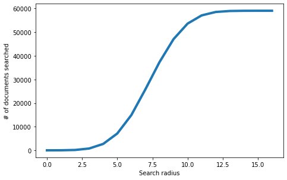

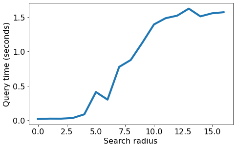

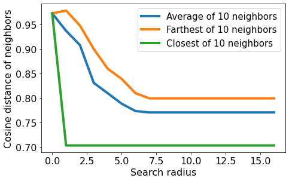

```python
plt.figure(figsize=(7,4.5))
plt.plot(num_candidates_history, linewidth=4)
plt.xlabel('Search radius')
plt.ylabel('# of documents searched')
plt.rcParams.update({'font.size':16})
plt.tight_layout()

plt.figure(figsize=(7,4.5))
plt.plot(query_time_history, linewidth=4)
plt.xlabel('Search radius')
plt.ylabel('Query time (seconds)')
plt.rcParams.update({'font.size':16})
plt.tight_layout()

plt.figure(figsize=(7,4.5))
plt.plot(average_distance_from_query_history, linewidth=4, label='Average of 10 neighbors')
plt.plot(max_distance_from_query_history, linewidth=4, label='Farthest of 10 neighbors')
plt.plot(min_distance_from_query_history, linewidth=4, label='Closest of 10 neighbors')
plt.xlabel('Search radius')
plt.ylabel('Cosine distance of neighbors')
plt.legend(loc='best', prop={'size':15})
plt.rcParams.update({'font.size':16})
plt.tight_layout()
```

```python
from __future__ import print_function # to conform python 2.x print to python 3.x
import turicreate
import matplotlib.pyplot as plt
import numpy as np
import sys
import os
from scipy.sparse import csr_matrix
from sklearn.preprocessing import OneHotEncoder, LabelEncoder

%matplotlib inline
```

```python
wiki = turicreate.SFrame('people_wiki.sframe/')
```

```python
wiki['tf_idf'] = turicreate.text_analytics.tf_idf(wiki['text'])
```

```python
def sframe_to_scipy(x, column_name):
    '''
    Convert a dictionary column of an SFrame into a sparse matrix format where
    each (row_id, column_id, value) triple corresponds to the value of
    x[row_id][column_id], where column_id is a key in the dictionary.

    Example
    >>> sparse_matrix, map_key_to_index = sframe_to_scipy(sframe, column_name)
    '''
    assert type(x[column_name][0]) == dict, \
        'The chosen column must be dict type, representing sparse data.'

    # 1. Add a row number (id)
    x = x.add_row_number()

    # 2. Stack will transform x to have a row for each unique (row, key) pair.
    x = x.stack(column_name, ['feature', 'value'])

    # Map feature words to integers
    unique_words = sorted(x['feature'].unique())
    mapping = {word:i for i, word in enumerate(unique_words)}
    x['feature_id'] = x['feature'].apply(lambda x: mapping[x])

    # Create numpy arrays that contain the data for the sparse matrix.
    row_id = np.array(x['id'])
    col_id = np.array(x['feature_id'])
    data = np.array(x['value'])

    width = x['id'].max() + 1
    height = x['feature_id'].max() + 1

    # Create a sparse matrix.
    mat = csr_matrix((data, (row_id, col_id)), shape=(width, height))
    return mat, mapping
```

```python
%%time
# The conversion will take about a minute or two.
tf_idf, map_index_to_word = sframe_to_scipy(wiki, 'tf_idf')
```

```
Using default 16 lambda workers.
```

```
To maximize the degree of parallelism, add the following code to the beginning of the program:
```

```
"turicreate.config.set_runtime_config('TURI_DEFAULT_NUM_PYLAMBDA_WORKERS', 32)"
```

```
Note that increasing the degree of parallelism also increases the memory footprint.
```

```
CPU times: user 3min 7s, sys: 13.5 s, total: 3min 21s
Wall time: 3min 13s
```

```python
tf_idf.shape
```

```
(59071, 547979)
```

```python
from sklearn.preprocessing import normalize
tf_idf = normalize(tf_idf)
```

```python
def get_initial_centroids(data, k, seed=None):
    '''Randomly choose k data points as initial centroids'''
    if seed is not None: # useful for obtaining consistent results
        np.random.seed(seed)
    n = data.shape[0] # number of data points

    # Pick K indices from range [0, N).
    rand_indices = np.random.randint(0, n, k)

    # Keep centroids as dense format, as many entries will be nonzero due to averaging.
    # As long as at least one document in a cluster contains a word,
    # it will carry a nonzero weight in the TF-IDF vector of the centroid.
    centroids = data[rand_indices,:].toarray()

    return centroids
```

```python
from sklearn.metrics import pairwise_distances

# Get the TF-IDF vectors for documents 100 through 102.
queries = tf_idf[100:102,:]

# Compute pairwise distances from every data point to each query vector.
dist = pairwise_distances(tf_idf, queries, metric='euclidean')

print(dist)
```

```
[[1.41000789 1.36894636]
 [1.40935215 1.41023886]
 [1.39855967 1.40890299]
 ...
 [1.41108296 1.39123646]
 [1.41022804 1.31468652]
 [1.39899784 1.41072448]]
```

```python
k = 3
centroids = tf_idf[:k,:]
distances = pairwise_distances(tf_idf, centroids, metric='euclidean')
print(distances)
dist = pairwise_distances(tf_idf[430,:], centroids[1], metric='euclidean')
print(dist)
```

```
[[0.         1.40775177 1.38784582]
 [1.40775177 0.         1.39867641]
 [1.38784582 1.39867641 0.        ]
 ...
 [1.37070999 1.40978937 1.40616385]
 [1.35214578 1.41306211 1.40869799]
 [1.40799024 1.41353429 1.40903605]]
[[1.40713107]]
```

```python
'''Test cell'''
if np.allclose(dist, pairwise_distances(tf_idf[430,:], tf_idf[1,:])):
    print('Pass')
else:
    print('Check your code again')
```

```
Pass
```

```python
closest_cluster = np.argmin(distances, 1)
closest_cluster
```

```
array([0, 1, 2, ..., 0, 0, 0])
```

```python
'''Test cell'''
reference = [list(row).index(min(row)) for row in distances]
if np.allclose(closest_cluster, reference):
    print('Pass')
else:
    print('Check your code again')
```

```
Pass
```

```python
def get_cluster_assignments(data, centroids):
    distances = pairwise_distances(data, centroids, metric='euclidean')
    return np.argmin(distances, 1)

cluster_assignment = get_cluster_assignments(tf_idf, centroids)
```

```python
if len(cluster_assignment)==59071 and \
   np.array_equal(np.bincount(cluster_assignment), np.array([23061, 10086, 25924])):
    print('Pass') # count number of data points for each cluster
else:
    print('Check your code again.')
```

```
Pass
```

```python
def assign_clusters(data, centroids):

    # Compute distances between each data point and the set of centroids:
    # Fill in the blank (RHS only)
    #distances_from_centroids = ...   # YOUR CODE HERE

    # Compute cluster assignments for each data point:
    # Fill in the blank (RHS only)
    cluster_assignment = get_cluster_assignments(data, centroids)   # YOUR CODE HERE

    return cluster_assignment
```

```python
if np.allclose(assign_clusters(tf_idf[0:100:10], tf_idf[0:8:2]), np.array([0, 1, 1, 0, 0, 2, 0, 2, 2, 1])):
    print('Pass')
else:
    print('Check your code again.')
```

```
Pass
```

```python
data = np.array([[1., 2., 0.],
                 [0., 0., 0.],
                 [2., 2., 0.]])
centroids = np.array([[0.5, 0.5, 0.],
                      [0., -0.5, 0.]])
```

```python
cluster_assignment = assign_clusters(data, centroids)
print(cluster_assignment)
```

```
[0 1 0]
```

```python
cluster_assignment==1
```

```
array([False,  True, False])
```

```python
cluster_assignment==0
```

```
array([ True, False,  True])
```

```python
data[cluster_assignment==1]
```

```
array([[0., 0., 0.]])
```

```python
data[cluster_assignment==0]
```

```
array([[1., 2., 0.],
       [2., 2., 0.]])
```

```python
data[cluster_assignment==0].mean(axis=0)
```

```
array([1.5, 2. , 0. ])
```

```python
def revise_centroids(data, k, cluster_assignment):
    new_centroids = []
    for i in range(k):
        # Select all data points that belong to cluster i. Fill in the blank (RHS only)
        member_data_points = data[cluster_assignment == i]   # YOUR CODE HERE
        # Compute the mean of the data points. Fill in the blank (RHS only)
        centroid = np.mean(member_data_points, axis=0)   # YOUR CODE HERE

        # Convert numpy.matrix type to numpy.ndarray type
        centroid = centroid.A1
        new_centroids.append(centroid)
    new_centroids = np.array(new_centroids)

    return new_centroids
```

```python
result = revise_centroids(tf_idf[0:100:10], 3, np.array([0, 1, 1, 0, 0, 2, 0, 2, 2, 1]))
if np.allclose(result[0], np.mean(tf_idf[[0,30,40,60]].toarray(), axis=0)) and \
   np.allclose(result[1], np.mean(tf_idf[[10,20,90]].toarray(), axis=0))   and \
   np.allclose(result[2], np.mean(tf_idf[[50,70,80]].toarray(), axis=0)):
    print('Pass')
else:
    print('Check your code')
```

```
Pass
```

```python
def compute_heterogeneity(data, k, centroids, cluster_assignment):

    heterogeneity = 0.0
    for i in range(k):

        # Select all data points that belong to cluster i. Fill in the blank (RHS only)
        member_data_points = data[cluster_assignment==i, :]

        if member_data_points.shape[0] > 0: # check if i-th cluster is non-empty
            # Compute distances from centroid to data points (RHS only)
            distances = pairwise_distances(member_data_points, [centroids[i]], metric='euclidean')
            squared_distances = distances**2
            heterogeneity += np.sum(squared_distances)

    return heterogeneity
```

```python
compute_heterogeneity(data, 2, centroids, cluster_assignment)
```

```
7.25
```

```python
# Fill in the blanks
def kmeans(data, k, initial_centroids, maxiter, record_heterogeneity=None, verbose=False):
    '''This function runs k-means on given data and initial set of centroids.
       maxiter: maximum number of iterations to run.
       record_heterogeneity: (optional) a list, to store the history of heterogeneity as function of iterations
                             if None, do not store the history.
       verbose: if True, print how many data points changed their cluster labels in each iteration'''
    centroids = initial_centroids[:]
    prev_cluster_assignment = None

    for itr in range(maxiter):
        if verbose:
            print(itr)

        # 1. Make cluster assignments using nearest centroids
        # YOUR CODE HERE
        cluster_assignment = assign_clusters(data, centroids)

        # 2. Compute a new centroid for each of the k clusters, averaging all data points assigned to that cluster.
        # YOUR CODE HERE
        centroids = revise_centroids(data, k, cluster_assignment)

        # Check for convergence: if none of the assignments changed, stop
        if prev_cluster_assignment is not None and \
          (prev_cluster_assignment==cluster_assignment).all():
            break

        # Print number of new assignments
        if prev_cluster_assignment is not None:
            num_changed = np.sum(prev_cluster_assignment!=cluster_assignment)
            if verbose:
                print('    {0:5d} elements changed their cluster assignment.'.format(num_changed))

        # Record heterogeneity convergence metric
        if record_heterogeneity is not None:
            # YOUR CODE HERE
            score = compute_heterogeneity(data, k, centroids, cluster_assignment)
            record_heterogeneity.append(score)

        prev_cluster_assignment = cluster_assignment[:]

    return centroids, cluster_assignment
```

```python
def plot_heterogeneity(heterogeneity, k):
    plt.figure(figsize=(7,4))
    plt.plot(heterogeneity, linewidth=4)
    plt.xlabel('# Iterations')
    plt.ylabel('Heterogeneity')
    plt.title('Heterogeneity of clustering over time, K={0:d}'.format(k))
    plt.rcParams.update({'font.size': 16})
    plt.tight_layout()
```

```
0
1
    19157 elements changed their cluster assignment.
2
     7739 elements changed their cluster assignment.
3
     5119 elements changed their cluster assignment.
4
     3370 elements changed their cluster assignment.
5
     2811 elements changed their cluster assignment.
6
     3233 elements changed their cluster assignment.
7
     3815 elements changed their cluster assignment.
8
     3172 elements changed their cluster assignment.
9
     1149 elements changed their cluster assignment.
10
      498 elements changed their cluster assignment.
11
      265 elements changed their cluster assignment.
12
      149 elements changed their cluster assignment.
13
      100 elements changed their cluster assignment.
14
       76 elements changed their cluster assignment.
15
       67 elements changed their cluster assignment.
16
       51 elements changed their cluster assignment.
17
       47 elements changed their cluster assignment.
18
       40 elements changed their cluster assignment.
19
       34 elements changed their cluster assignment.
20
```

[output cut: 65 more lines]

```
53
        3 elements changed their cluster assignment.
54
        4 elements changed their cluster assignment.
55
        2 elements changed their cluster assignment.
56
        3 elements changed their cluster assignment.
57
        3 elements changed their cluster assignment.
58
        1 elements changed their cluster assignment.
59
        1 elements changed their cluster assignment.
60
```

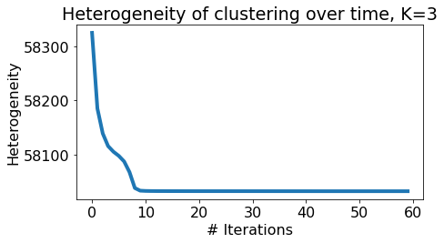

```python
k = 3
heterogeneity = []
initial_centroids = get_initial_centroids(tf_idf, k, seed=0)
centroids, cluster_assignment = kmeans(tf_idf, k, initial_centroids, maxiter=400,
                                       record_heterogeneity=heterogeneity, verbose=True)
plot_heterogeneity(heterogeneity, k)
```

```python
np.bincount(cluster_assignment)
```

```
array([19595, 10427, 29049])
```

```python
k = 10
heterogeneity = {}
cluster_assignment_dict = {}
import time
start = time.time()
for seed in [0, 20000, 40000, 60000, 80000, 100000, 120000]:
    initial_centroids = get_initial_centroids(tf_idf, k, seed)
    centroids, cluster_assignment = kmeans(tf_idf, k, initial_centroids, maxiter=400,
                                           record_heterogeneity=None, verbose=False)
    # To save time, compute heterogeneity only once in the end
    heterogeneity[seed] = compute_heterogeneity(tf_idf, k, centroids, cluster_assignment)

    # This is the line we added for the next quiz question
    cluster_assignment_dict[seed] = np.bincount(cluster_assignment)

#    print('seed={0:06d}, heterogeneity={1:.5f}'.format(seed, heterogeneity[seed]))
    # And this is the modified print statement
    print('seed={0:06d}, heterogeneity={1:.5f}, cluster_distribution={2}'.format(seed, heterogeneity[seed],
                                           cluster_assignment_dict[seed]))
    sys.stdout.flush()
end = time.time()
print(end-start)
```

```
seed=000000, heterogeneity=57457.52442, cluster_distribution=[18047  3824  5671  6983  1492  1730  3882  3449  7139  6854]
seed=020000, heterogeneity=57533.20100, cluster_distribution=[ 3142   768  3566  2277 15779  7278  6146  7964  6666  5485]
seed=040000, heterogeneity=57512.69257, cluster_distribution=[ 5551  6623   186  2999  8487  3893  6807  2921  3472 18132]
seed=060000, heterogeneity=57466.97925, cluster_distribution=[ 3014  3089  6681  3856  8080  7222  3424   424  5381 17900]
seed=080000, heterogeneity=57494.92990, cluster_distribution=[17582  1785  7215  3314  6285   809  5930  6791  5536  3824]
seed=100000, heterogeneity=57484.42210, cluster_distribution=[ 6618  1337  6191  2890 16969  4983  5242  3892  5562  5387]
seed=120000, heterogeneity=57554.62410, cluster_distribution=[ 6118  5841  4964  8423  4302  3183 16481  1608  5524  2627]
129.29057931900024
```

```python
def smart_initialize(data, k, seed=None):
    '''Use k-means++ to initialize a good set of centroids'''
    if seed is not None: # useful for obtaining consistent results
        np.random.seed(seed)
    centroids = np.zeros((k, data.shape[1]))

    # Randomly choose the first centroid.
    # Since we have no prior knowledge, choose uniformly at random
    idx = np.random.randint(data.shape[0])
    centroids[0] = data[idx,:].toarray()
    # Compute distances from the first centroid chosen to all the other data points
    squared_distances = pairwise_distances(data, centroids[0:1], metric='euclidean').flatten()**2

    for i in range(1, k):
        # Choose the next centroid randomly, so that the probability for each data point to be chosen
        # is directly proportional to its squared distance from the nearest centroid.
        # Roughtly speaking, a new centroid should be as far as from ohter centroids as possible.
        idx = np.random.choice(data.shape[0], 1, p=squared_distances/sum(squared_distances))
        centroids[i] = data[idx,:].toarray()
        # Now compute distances from the centroids to all data points
        squared_distances = np.min(pairwise_distances(data, centroids[0:i+1], metric='euclidean')**2,axis=1)

    return centroids
```

```python
%%time

k = 10
heterogeneity_smart = {}
seeds = [0, 20000, 40000, 60000, 80000, 100000, 120000]
for seed in seeds:
    initial_centroids = smart_initialize(tf_idf, k, seed)
    centroids, cluster_assignment = kmeans(tf_idf, k, initial_centroids, maxiter=400,
                                           record_heterogeneity=None, verbose=False)
    # To save time, compute heterogeneity only once in the end
    heterogeneity_smart[seed] = compute_heterogeneity(tf_idf, k, centroids, cluster_assignment)
    print('seed={0:06d}, heterogeneity={1:.5f}'.format(seed, heterogeneity_smart[seed]))
    sys.stdout.flush()
```

```
seed=000000, heterogeneity=57468.63808
seed=020000, heterogeneity=57486.94263
seed=040000, heterogeneity=57454.35926
seed=060000, heterogeneity=57530.43659
seed=080000, heterogeneity=57454.51852
seed=100000, heterogeneity=57471.56674
seed=120000, heterogeneity=57523.28839
CPU times: user 2min 34s, sys: 4.72 s, total: 2min 39s
Wall time: 2min 39s
```

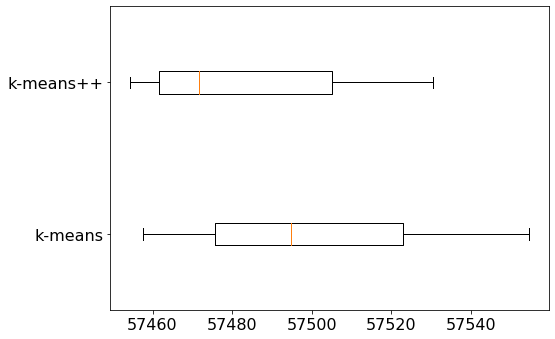

```python
plt.figure(figsize=(8,5))
plt.boxplot([list(heterogeneity.values()), list(heterogeneity_smart.values())], vert=False)
plt.yticks([1, 2], ['k-means', 'k-means++'])
plt.rcParams.update({'font.size': 16})
plt.tight_layout()
```

```python
def kmeans_multiple_runs(data, k, maxiter, num_runs, seed_list=None, verbose=False):
    heterogeneity = {}

    min_heterogeneity_achieved = float('inf')
    best_seed = None
    final_centroids = None
    final_cluster_assignment = None

    for i in range(num_runs):

        # Use UTC time if no seeds are provided
        if seed_list is not None:
            seed = seed_list[i]
            np.random.seed(seed)
        else:
            seed = int(time.time())
            np.random.seed(seed)

        # Use k-means++ initialization
        # YOUR CODE HERE
        initial_centroids = smart_initialize(data, k, seed)

        # Run k-means
        # YOUR CODE HERE
        centroids, cluster_assignment = kmeans(tf_idf, k, initial_centroids, maxiter=400,
                                           record_heterogeneity=None, verbose=False)

        # To save time, compute heterogeneity only once in the end
        # YOUR CODE HERE
        heterogeneity[seed] = compute_heterogeneity(tf_idf, k, centroids, cluster_assignment)

        if verbose:
            print('seed={0:06d}, heterogeneity={1:.5f}'.format(seed, heterogeneity[seed]))
            sys.stdout.flush()

        # if current measurement of heterogeneity is lower than previously seen,
        # update the minimum record of heterogeneity.
        if heterogeneity[seed] < min_heterogeneity_achieved:
            min_heterogeneity_achieved = heterogeneity[seed]
            best_seed = seed
            final_centroids = centroids
            final_cluster_assignment = cluster_assignment

    # Return the centroids and cluster assignments that minimize heterogeneity.
    return final_centroids, final_cluster_assignment
```

```python
%%time
import numpy as np

def plot_k_vs_heterogeneity(k_values, heterogeneity_values):
    plt.figure(figsize=(7,4))
    plt.plot(k_values, heterogeneity_values, linewidth=4)
    plt.xlabel('K')
    plt.ylabel('Heterogeneity')
    plt.title('K vs. Heterogeneity')
    plt.rcParams.update({'font.size': 16})
    plt.tight_layout()

centroids = {}
cluster_assignment = {}
heterogeneity_values = []
k_list = [2, 10, 25, 50, 100]
#seed_list = [0]
# Uncomment the following line to run the plot with all the seeds (it may take about an hour to finish).
seed_list = [0, 20000, 40000, 60000, 80000, 100000, 120000]

for k in k_list:
    heterogeneity = []
    centroids[k], cluster_assignment[k] = kmeans_multiple_runs(tf_idf, k, maxiter=400,
                                                               num_runs=len(seed_list),                                                               seed_list=seed_list,
                                                               verbose=True)
    score = compute_heterogeneity(tf_idf, k, centroids[k], cluster_assignment[k])
    heterogeneity_values.append(score)
```

```
seed=000000, heterogeneity=58224.59913
seed=020000, heterogeneity=58179.57453
seed=040000, heterogeneity=58179.57453
seed=060000, heterogeneity=58179.57453
seed=080000, heterogeneity=58224.59952
seed=100000, heterogeneity=58179.57453
seed=120000, heterogeneity=58179.57453
seed=000000, heterogeneity=57468.63808
seed=020000, heterogeneity=57486.94263
seed=040000, heterogeneity=57454.35926
seed=060000, heterogeneity=57530.43659
seed=080000, heterogeneity=57454.51852
seed=100000, heterogeneity=57471.56674
seed=120000, heterogeneity=57523.28839
seed=000000, heterogeneity=56913.24052
seed=020000, heterogeneity=56961.01793
seed=040000, heterogeneity=56904.99744
seed=060000, heterogeneity=56858.67830
seed=080000, heterogeneity=56955.74619
seed=100000, heterogeneity=56973.02116
seed=120000, heterogeneity=56934.20148
seed=000000, heterogeneity=56399.72145
seed=020000, heterogeneity=56322.64583
seed=040000, heterogeneity=56314.32239
seed=060000, heterogeneity=56278.53939
seed=080000, heterogeneity=56353.54891
seed=100000, heterogeneity=56303.94021
seed=120000, heterogeneity=56361.37319
seed=000000, heterogeneity=55649.66538
seed=020000, heterogeneity=55587.56988
seed=040000, heterogeneity=55720.24668
seed=060000, heterogeneity=55616.64653
seed=080000, heterogeneity=55672.95812
seed=100000, heterogeneity=55660.45384
seed=120000, heterogeneity=55735.28103
CPU times: user 33min 27s, sys: 3min 48s, total: 37min 16s
Wall time: 37min 10s
```

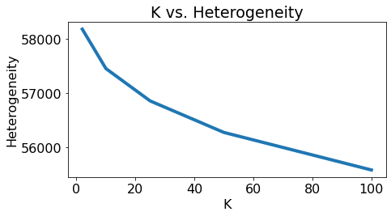

```python
plot_k_vs_heterogeneity(k_list, heterogeneity_values)
```

```python
def visualize_document_clusters(wiki, tf_idf, centroids, cluster_assignment, k, map_word_to_index, display_content=True):
    '''wiki: original dataframe
       tf_idf: data matrix, sparse matrix format
       map_index_to_word: SFrame specifying the mapping betweeen words and column indices
       display_content: if True, display 8 nearest neighbors of each centroid'''
    map_index_to_word =  {v:k for k,v in map_word_to_index.items()}
    print('==========================================================')
    # Visualize each cluster c
    for c in range(k):
        # Cluster heading
        print('Cluster {0:d}    '.format(c)),
        # Print top 5 words with largest TF-IDF weights in the cluster
        idx = centroids[c].argsort()[::-1]
        for i in range(5): # Print each word along with the TF-IDF weight
            print('{0:s}:{1:.3f}'.format(map_index_to_word[idx[i]], centroids[c][idx[i]])),
        print('')

        if display_content:
            # Compute distances from the centroid to all data points in the cluster,
            # and compute nearest neighbors of the centroids within the cluster.
            distances = pairwise_distances(tf_idf, centroids[c].reshape(1, -1), metric='euclidean').flatten()
            distances[cluster_assignment!=c] = float('inf') # remove non-members from consideration

            nearest_neighbors = distances.argsort()

            # For 8 nearest neighbors, print the title as well as first 180 characters of text.
            # Wrap the text at 80-character mark.
            for i in range(8):
                text = ' '.join(wiki[nearest_neighbors[i]]['text'].split(None, 25)[0:25])
                print('\n* {0:50s} {1:.5f}\n  {2:s}\n  {3:s}'.format(wiki[nearest_neighbors[i]]['name'],
                    distances[nearest_neighbors[i]], text[:90], text[90:180] if len(text) > 90 else ''))
        print('==========================================================')
```

```python
'''Notice the extra pairs of parentheses for centroids and cluster_assignment.
   The centroid and cluster_assignment are still inside the npz file,
   and we need to explicitly indicate when to load them into memory.'''
visualize_document_clusters(wiki, tf_idf, centroids[2], cluster_assignment[2], 2, map_index_to_word)
```

```
==========================================================
Cluster 0
she:0.021
university:0.015
her:0.013
he:0.012
served:0.010


* Kayee Griffin                                      0.97358
  kayee frances griffin born 6 february 1950 is an australian politician and former australi
  an labor party member of the new south wales legislative council serving

* %C3%81ine Hyland                                   0.97370
  ine hyland ne donlon is emeritus professor of education and former vicepresident of univer
  sity college cork ireland she was born in 1942 in athboy co

* Christine Robertson                                0.97373
  christine mary robertson born 5 october 1948 is an australian politician and former austra
  lian labor party member of the new south wales legislative council serving

* Anita Kunz                                         0.97471
  anita e kunz oc born 1956 is a canadianborn artist and illustratorkunz has lived in london
   new york and toronto contributing to magazines and working

* Barry Sullivan (lawyer)                            0.97488
  barry sullivan is a chicago lawyer and as of july 1 2009 the cooney conway chair in advoca
  cy at loyola university chicago school of law

* Margaret Catley-Carlson                            0.97534
  margaret catleycarlson oc born 6 october 1942 is a canadian civil servant she was chair an
  d is now a patron of the global water partnership

* Vanessa Gilmore                                    0.97579
  vanessa diane gilmore born october 1956 is a judge on the united states district court for
   the southern district of texas she was appointed to

* James A. Joseph                                    0.97624
  james a joseph born 1935 is an american former diplomatjoseph is professor of the practice
   of public policy studies at duke university and founder of
```

[output cut: 26 more lines]

```
  todd michael williams born february 13 1971 in syracuse new york is a former major league
  baseball relief pitcher he attended east syracuseminoa high school

* Marilyn Jenkins                                    0.97430
  marilyn a jenkins jenks born september 18 1934 is a former catcher who played in the allam
  erican girls professional baseball league listed at 5 ft

* Kayla Bashore Smedley                              0.97496
  kayla bashore born february 20 1983 in daegu south korea is an american field hockey defen
  der and midfielder now living in san diego california she

* Cher                                               0.97510
  cher r born cherilyn sarkisian may 20 1946 is an american singer actress and television ho
  st described as embodying female autonomy in a maledominated industry
==========================================================
```

```python
k = 10
visualize_document_clusters(wiki, tf_idf, centroids[k], cluster_assignment[k], k, map_index_to_word)
```

```
==========================================================
Cluster 0
he:0.012
art:0.011
his:0.009
book:0.008
that:0.008


* Wilson McLean                                      0.97661
  wilson mclean born 1937 is a scottish illustrator and artist he has illustrated primarily
  in the field of advertising but has also provided cover art

* Tang Xiyang                                        0.97988
  tang xiyang born january 30 1930 in miluo hunan province is a chinese environmentalist he
  was awarded the 2007 ramon magsaysay award for peace and

* David Salle                                        0.98168
  david salle born 1952 is an american painter printmaker and stage designer who helped defi
  ne postmodern sensibility salle was born in norman oklahoma he earned

* Alberto Blanco (poet)                              0.98172
  alberto blanco is considered one of mexicos most important poets born in mexico city on fe
  bruary 18 1951 he spent his childhood and adolescence in

* John Donald (jewellery designer)                   0.98290
  john donald is a british jeweller designer whose work is strongly identified in the 1960s
  and 1970s in london princess margaret and the queen mother

* David Elliott (curator)                            0.98298
  david stuart elliott born 29 april 1949 is a britishborn art gallery and museum curator an
  d writer about modern and contemporary arthe was educated at

* Chris Hunt                                         0.98307
  chris hunt is a british journalist magazine editor and author he has worked in journalism
  for over twenty years most often writing about football or

* Kcho                                               0.98342
  kchosometimes spelled kcho born alexis leiva machado on the isla de pinos 1970 is a contem
  porary cuban artist kcho has had art showings around the
```

[output cut: 346 more lines]

```
  catherine hakim born 30 may 1948 is a british sociologist who specialises in womens employ
  ment and womens issues she is currently a professorial research fellow

* Daniel Berg (educator)                             0.96361
  daniel berg is a scientist educator and was the fifteenth president of rensselaer polytech
  nic institutehe was born on june 1 1929 in new york city

* Georg von Krogh                                    0.96375
  georg von krogh was born in oslo norway he is a professor at eth zurich and holds the chai
  r of strategic management and innovation he

* Martin Apple                                       0.96381
  martin a apple is president of the council of scientific society presidents cssp an organi
  zation of presidents of some sixty scientific federations and societies whose
==========================================================
```

```python
np.bincount(cluster_assignment[10])
```

```
array([19618,  3857,  4173,  5219,  1743,  6900,  5530,  1348,  4384,
        6299])
```

```python
visualize_document_clusters(wiki, tf_idf, centroids[25], cluster_assignment[25], 25,
                            map_index_to_word, display_content=False) # turn off text for brevity
```

```
==========================================================
Cluster 0
poetry:0.053
novel:0.043
book:0.042
published:0.039
fiction:0.034

==========================================================
Cluster 1
film:0.100
theatre:0.039
films:0.036
directed:0.029
actor:0.028

==========================================================
Cluster 2
law:0.143
court:0.087
judge:0.066
district:0.045
justice:0.042

==========================================================
Cluster 3
republican:0.061
senate:0.050
district:0.044
state:0.039
democratic:0.037

==========================================================
Cluster 4
music:0.114
piano:0.047
orchestra:0.039
composition:0.038
composer:0.034

```

[output cut: 146 more lines]

```
band:0.104
album:0.049
rock:0.031
guitar:0.031
bands:0.030

==========================================================
Cluster 24
football:0.057
coach:0.053
season:0.047
basketball:0.042
played:0.039

==========================================================
```

```python
k=100
visualize_document_clusters(wiki, tf_idf, centroids[k], cluster_assignment[k], k,
                            map_index_to_word, display_content=False)
# turn off text for brevity -- turn it on if you are curious ;)
```

```
==========================================================
Cluster 0
psychology:0.195
psychological:0.066
research:0.057
psychologist:0.045
cognitive:0.041

==========================================================
Cluster 1
film:0.213
festival:0.060
films:0.054
directed:0.039
feature:0.037

==========================================================
Cluster 2
law:0.146
court:0.097
judge:0.074
district:0.051
justice:0.045

==========================================================
Cluster 3
mayor:0.137
city:0.049
council:0.040
elected:0.032
election:0.030

==========================================================
Cluster 4
music:0.147
composition:0.048
composer:0.047
orchestra:0.026
composers:0.025

```

[output cut: 746 more lines]

```
opera:0.227
ballet:0.088
she:0.065
la:0.036
her:0.034

==========================================================
Cluster 99
art:0.208
museum:0.149
gallery:0.085
arts:0.043
contemporary:0.041

==========================================================
```

```python
sum(np.bincount(cluster_assignment[k]) < 236) / k
```

```
0.33
```

```python
k
```

```
100
```

```python
sum(np.bincount(cluster_assignment[k]) < 236)
```

```
33
```

```python
!unzip images.sf.zip
```

```
Archive:  images.sf.zip
replace images.sf/m_eb749d4e5da0750d.frame_idx? [y]es, [n]o, [A]ll, [N]one, [r]ename:
```